# Risk factors in accidental drug related deaths.

## 0.1 Preliminaries

```r
library(forcats)
library(broom)
library(skimr)
library(modelr)
library(Hmisc)
library(tidyverse)
library(tableone)
library(ROCR)
```

# 1 Task-1 Data Source

Accidental Drug Related Deaths 2012-June 2017 in Connecticut (CT). This data set is readily available at the following website, which is open for all the public users. https://catalog.data.gov/dataset/accidental-drug-related-deaths-january-2012-sept-2015/resource/44580a89-a260-4844-8ead-35736f395389

Accidental Drug Related Deaths are increasing in USA. This dataset contains information regarding multiple drug overdose related accidents form 2012 - June 2017 in Connecticut area. A “Y” value under the different substance columns indicates that particular substance was detected in the person. Data are derived from an investigation by the Office of the Chief Medical Examiner which includes the toxicity report, death certificate, as well as a scene investigation.

In this study, I am planning to evaluate if Alcohol consumption is a risk factor to increase overdose related death. In Connecticut drinking age limit is 20. I want to evaluate if drug overdose related accidents are more common in alcohol drinkers. The original dataset contain several other drugs. However, I restrict my study on major drugs, which are Heroin, Cocaine, Fentanyl, Oxycodone, Oxymorphone and Alcohol.

# 2 Task-2 Load and tidy the dataset

```r
project_1<-read.csv("Accidental_Drug_related_deaths-2.csv", stringsAsFactors=FALSE)%>%tbl_df()
project_1$Heroin<-fct_recode(project_1$Heroin,
           Y = "y",
           N = "",
           N2 = " ")
project_1$Heroin<-fct_recode(project_1$Heroin,
           N = "N2")
project_1$Cocaine<-fct_recode(project_1$Cocaine,
           Y = "y",
           N = "")
project_1$Fentanyl<-fct_recode(project_1$Fentanyl,
           Y = "y",
           Y1="Y ",
           N = "")
project_1$Fentanyl<-fct_recode(project_1$Fentanyl,
           Y = "Y1")
project_1$Oxycodone<-fct_recode(project_1$Oxycodone,
           Y = "y",
           N = "")
project_1$Oxymorphone<-fct_recode(project_1$Oxymorphone,
           Y = "y",
           N = "")
project_1$Alcohol<-fct_recode(project_1$Alcohol,
           Y = "y",
           N = "")
project_1
```

```
# A tibble: 999 x 13
   CaseNumber       Date    Sex            Race   Age  Death_City
        <chr>      <chr>  <chr>           <chr> <int>       <chr>
 1   13-16336  11/9/2013 Female           White    53      GROTON
 2   12-18447 12/29/2012   Male           White    30   WATERBURY
 3    14-2758  2/18/2014   Male           White    43     ENFIELD
 4   14-13497   9/7/2014 Female           White    24 WALLINGFORD
 5   13-14421  10/4/2013 Female           White    26  WEST HAVEN
 6   13-18018 12/10/2013 Female           White    45     DANBURY
 7   13-19004 12/27/2013   Male           White    55  BRIDGEPORT
 8    13-3783   3/4/2013   Male Hispanic, White    47   NEW HAVEN
 9    14-5669   4/9/2014 Female           White    53     DANBURY
10    13-9675  6/28/2013   Male           White    29   WATERBURY
# ... with 989 more rows, and 7 more variables: Location <chr>,
#   Heroin <fctr>, Cocaine <fctr>, Fentanyl <fctr>, Oxycodone <fctr>,
#   Oxymorphone <fctr>, Alcohol <fctr>
```

```r
project_1$Location<-fct_recode(project_1$Location)
project_1$Death_City<-fct_recode(project_1$Death_City)
project_1$Race<-fct_recode(project_1$Race,
           Black = "Hispanic, Black")
          project_1$Sex<-fct_recode(project_1$Sex)
project_1
```

```
# A tibble: 999 x 13
   CaseNumber       Date    Sex            Race   Age  Death_City
        <chr>      <chr> <fctr>          <fctr> <int>      <fctr>
 1   13-16336  11/9/2013 Female           White    53      GROTON
 2   12-18447 12/29/2012   Male           White    30   WATERBURY
 3    14-2758  2/18/2014   Male           White    43     ENFIELD
 4   14-13497   9/7/2014 Female           White    24 WALLINGFORD
 5   13-14421  10/4/2013 Female           White    26  WEST HAVEN
 6   13-18018 12/10/2013 Female           White    45     DANBURY
 7   13-19004 12/27/2013   Male           White    55  BRIDGEPORT
 8    13-3783   3/4/2013   Male Hispanic, White    47   NEW HAVEN
 9    14-5669   4/9/2014 Female           White    53     DANBURY
10    13-9675  6/28/2013   Male           White    29   WATERBURY
# ... with 989 more rows, and 7 more variables: Location <fctr>,
#   Heroin <fctr>, Cocaine <fctr>, Fentanyl <fctr>, Oxycodone <fctr>,
#   Oxymorphone <fctr>, Alcohol <fctr>
```

There are total 13 variables(column) in the dataset with 999(rows) observations. There was only one “black hispanic race”" individual, I recode it as “Black”.

# 3 Task 3: Listing of My Tibble

```r
summary(project_1)
```

```
  CaseNumber            Date               Sex                   Race
 Length:999         Length:999         Female:290   Asian, Other   :  5
 Class :character   Class :character   Male  :709   Black          : 68
 Mode  :character   Mode  :character                Hispanic, White:101
                                                    Unknown        :  9
                                                    White          :816


      Age             Death_City       Location   Heroin  Cocaine Fentanyl
 Min.   :14.00   HARTFORD  : 89            :  2   N:322   N:725   N:864
 1st Qu.:31.00   WATERBURY : 81   Hospital :345   Y:677   Y:274   Y:135
 Median :42.00   NEW HAVEN : 76   Other    :145
 Mean   :41.72   BRIDGEPORT: 62   Residence:505
 3rd Qu.:51.00   NEW LONDON: 44   NA's     :  2
 Max.   :75.00   (Other)   :646
                 NA's      :  1
 Oxycodone Oxymorphone Alcohol
 N:820     N:948       N:738
 Y:179     Y: 51       Y:261
```

```r
map_df(project_1, function(x) sum(is.na(x)))
```

```
# A tibble: 1 x 13
  CaseNumber  Date   Sex  Race   Age Death_City Location Heroin Cocaine
       <int> <int> <int> <int> <int>      <int>    <int>  <int>   <int>
1          0     0     0     0     0          1        2      0       0
# ... with 4 more variables: Fentanyl <int>, Oxycodone <int>,
#   Oxymorphone <int>, Alcohol <int>
```

There are total 13 variables (column) in the dataset with 999(rows) observations. There is 1 missing death city and 2 missing death locations.

To finalize the variables and simplify the dataset, Location and Death_City variables are deleted from the data.

```r
project_1F <- subset( project_1, select = -c(Location, Death_City ) )
project_1F
```

```
# A tibble: 999 x 11
   CaseNumber       Date    Sex            Race   Age Heroin Cocaine
        <chr>      <chr> <fctr>          <fctr> <int> <fctr>  <fctr>
 1   13-16336  11/9/2013 Female           White    53      N       N
 2   12-18447 12/29/2012   Male           White    30      N       Y
 3    14-2758  2/18/2014   Male           White    43      N       N
 4   14-13497   9/7/2014 Female           White    24      Y       N
 5   13-14421  10/4/2013 Female           White    26      Y       N
 6   13-18018 12/10/2013 Female           White    45      Y       N
 7   13-19004 12/27/2013   Male           White    55      Y       N
 8    13-3783   3/4/2013   Male Hispanic, White    47      Y       Y
 9    14-5669   4/9/2014 Female           White    53      N       Y
10    13-9675  6/28/2013   Male           White    29      Y       N
# ... with 989 more rows, and 4 more variables: Fentanyl <fctr>,
#   Oxycodone <fctr>, Oxymorphone <fctr>, Alcohol <fctr>
```

# 4 Task-4 Code book

| Variable | Type | Details |
| --- | --- | --- |
| `Case Number` | character | Drug overdose related deaths identification code |
| `Date` | character | the date on which person died due to drug overdose |
| `Sex` | binary | sex (female, male) of a person died |
| `Race` | multi-categorical | Race of a dead person (white, hispanic white, black or hispanic black, Asian and other) |
| `Age` | quantitative | Person’s age at death |
| `Heroin` | binary | person intoxicated with heroin at the time of death Y=Yes, N= No |
| `Cocaine` | binary | person intoxicated with Cocaine at the time of death Y=Yes,N= No |
| `Fentanyl` | binary | person intoxicated with Fentanyl at the time of death Y=Yes,N= No |
| `Oxycodone` | binary | person intoxicated with Oxycodone at the time of death Y=Yes,N= No |
| `Oxymorphone` | binary | person intoxicated with Oxymorphone at the time of death Y=Yes, N= No |
| `Alcohol` | binary | person intoxicated with Alcohol at the time of death Y=Yes, N= No |

# 5 Task 5: My Subjects

There are 999 rows in the dataset. Each row describes a person who died by drug overdose in the Connecticut area between 2012-2015.

# 6 Task 6: My Variables

There are total 11 variables(column) in the dataset with 999(rows) observations.

1. CaseNumber This is a person’s identification code.
2. Date This is the day when person died due to drug overdose or substance abuse. 3.Sex This is a gender female and male died due to drug overdose or substance abuse.
3. Race This is the person’s race.
4. Age Age of the person at the time of death.
5. Heroin Person intoxicated with heroin at the time of death Y=Yes, N= No
6. Cocaine Person intoxicated with cocaine at the time of death Y=Yes, N= No
7. Fentanyl Person intoxicated with fentanyl at the time of death Y=Yes, N= No
8. Oxycodone Person intoxicated with Oxycodone at the time of death Y=Yes, N= No
9. Oxymorphone Person intoxicated with Oxymorphone at the time of death Y=Yes, N= No 11.Alcohol Person intoxicated with alcohol at the time of death Y=Yes, N= No

# 7 Task-7 Linear Regression Model

Predict the quantitative outcome Age using some combination of the following seven variables: 1. Race 2. Sex 3. Heroin 4. Cocaine 5. Fentanyl 6. Oxymorphone 7. Alcohol

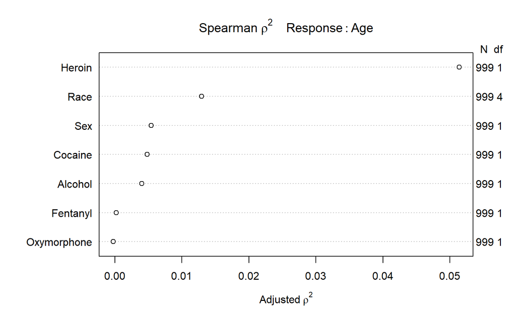

```r
plot(spearman2(Age ~ Race+Sex+Heroin+Cocaine+Fentanyl+Oxymorphone+Alcohol, data=project_1F))
```

# 8 Task-8 Logistic Regression model

We will predict the binary outcome Alcohol using some combination of the following seven variables:

1. Race
2. Sex
3. Heroin
4. cocaine
5. Fentanyl
6. Oxycodone
7. Oxymorphone

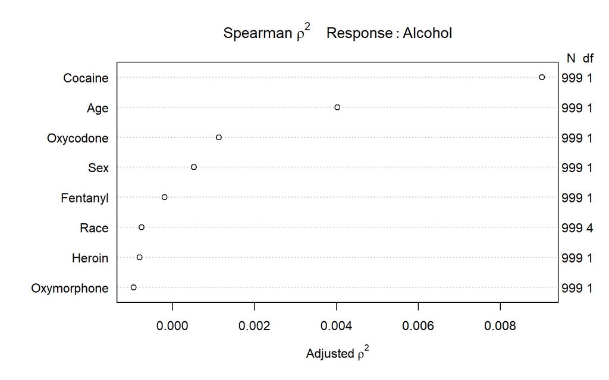

```r
plot(spearman2(Alcohol~Heroin+Age+Race+Sex+Heroin+Cocaine+Fentanyl+Oxycodone+Oxymorphone, data=project_1F))
```

# 9 Task 9: Affirmation

This data set meets almost all requirements specified in the project instructions. This dataset describes 999 deaths due to substance abuse or drug overdose.  
I am considering atleat seven predictors for each regression model, and include at least one quantitative (Age) and Race as a multi-categorical variable in each model. This dataset can be shared with anyone without any conditions.

Preeti Pathak

2018-02-26 13:10:59